# PROB1st Modelling (Machine Learning)

Di

Jan, 2016

### Purpose

- Find best algorithm to predict incoming students (PAG incoming cohorts) who will be on probation at 1st fall
- Time of prediction : As of the first day of class, therefore, predictors included are admission and other students info as their first day of class
- Intepretability might be traded off with better model accuracy

#### Descriptive analyses for data exploration

- probation rate by cohort (End Academic Status <> ‘GOOD’): varies from 8-10% in the past 6 cohorts

```
# A tibble: 6 × 3
  COHORT    hc   probrate
   <int> <int>      <dbl>
1   2010  7185 0.08740431
2   2011  7815 0.09136276
3   2012  8192 0.09472656
4   2013  7877 0.10384664
5   2014  7878 0.09634425
6   2015  7958 0.08381503
```

- 1. Relationship with PRED_GPA (known predicting factor)
- 1st fall probation by pred_GPA group
- note : 26% probation cases came from PRED_GPA unknown group

```
                  N     Y   Sum
  [1.28,2.85)  7999  2015 10014
  [2.85,3.08)  9224   762  9986
  [3.08,3.27)  9656   331  9987
  [3.27,4.59]  9861   127  9988
  unknown      5803  1127  6930
  Sum         42543  4362 46905
```

```
                       N          Y
  [1.28,2.85) 0.79878171 0.20121829
  [2.85,3.08) 0.92369317 0.07630683
  [3.08,3.27) 0.96685691 0.03314309
  [3.27,4.59] 0.98728474 0.01271526
  unknown     0.83737374 0.16262626
```

```
                       N          Y
  [1.28,2.85) 0.18802153 0.46194406
  [2.85,3.08) 0.21681593 0.17469051
  [3.08,3.27) 0.22697036 0.07588262
  [3.27,4.59] 0.23178901 0.02911508
  unknown     0.13640317 0.25836772
```

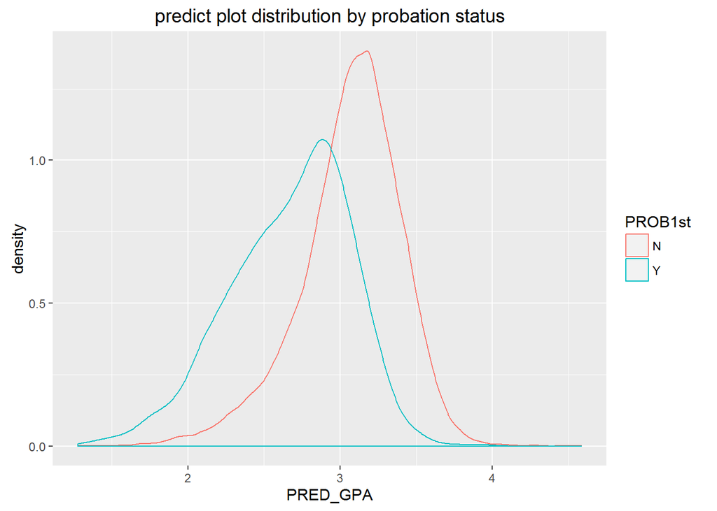

- Relationship between PRED_GPA and CUM GPA FS1 in general
- Once the PRED_GPA >=3,students are mostly scattered in ‘good’ (cum GPA FS1 >=2.0) *the overall fit is more like a S shape curve with more variations at either ends

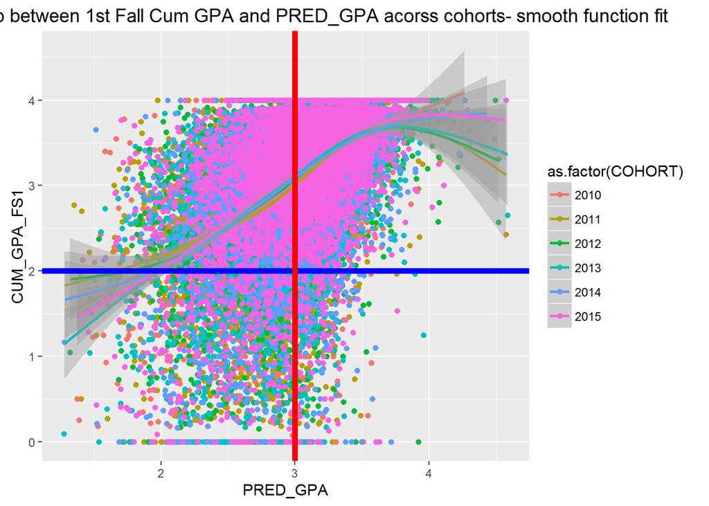

- Note that there are less than 3% of the incoming population whose MUS GPA credits in the first Fall is Zero, by rule, they were not put on probation regardless of their CUM GPA FS1

**data shows 95% of those zero credit GPA can be found at the first day of class registration**

```
[1] 0.9481752
```

### In addition to predict GPA, other factors considered

- FW courses registration:
- DFW course : DFW table, courses with at least 100 enrollees and DFW rates >=10%
- Using the first day class SISPCRS, looking for number of courses that the student registered are DFW courses. Calculate the DFW course % (pctdfw) **t test shows the Probation population has higher dfw course %**

```
$N
   Min. 1st Qu.  Median    Mean 3rd Qu.    Max.
0.00000 0.00000 0.00000 0.05295 0.00000 1.00000

$Y
   Min. 1st Qu.  Median    Mean 3rd Qu.    Max.
0.00000 0.00000 0.00000 0.08887 0.20000 1.00000
```

```
    Welch Two Sample t-test

data:  PAG$pctdfw by PAG$PROB1st
t = -17.368, df = 4955.2, p-value < 2.2e-16
alternative hypothesis: true difference in means is not equal to 0
95 percent confidence interval:
 -0.03996422 -0.03185745
sample estimates:
mean in group N mean in group Y
     0.05295485      0.08886569
```

- 2). AOP dates:
- dategrp : numbers of days that AOP happened prior to the first day of class

**AOP date prior to first day of class associated with PROB1st signifcantly**

```
                             N           Y
  [0-30)           0.811341943 0.188658057
  [30-60)          0.904252474 0.095747526
  [60,80)          0.934617903 0.065382097
  80+              0.940263770 0.059736230
  After Term Start 0.991513437 0.008486563
  N                0.927436075 0.072563925
```

```
    Pearson's Chi-squared test

data:  table(PAG$dategrp, PAG$PROB1st)
X-squared = 1051.5, df = 5, p-value < 2.2e-16
```

- 3). residence hall:
- using SISPADR_FIRSTDAY to find out which residence hall the students lived as first day of class. using HO adr1 text description to group the adress into : Brody, North, East,River Trail, south, offcampus

**residence as first day of class associated with PROB1st signficantly**

```
                       N          Y
  Brody       0.92224304 0.07775696
  East        0.89234297 0.10765703
  North       0.93491347 0.06508653
  Off-Campus  0.90187333 0.09812667
  River Trail 0.90722166 0.09277834
  South       0.90495868 0.09504132
```

```
    Pearson's Chi-squared test

data:  table(PAG$residhall, PAG$PROB1st)
X-squared = 110.68, df = 5, p-value < 2.2e-16
```

- 4. AP credits
- using SISPTRN_FIRSTDAY AP credits through ETSADPL

**AP credits associated with PROB1st signficantly**

```
    Welch Two Sample t-test

data:  APcredit by PROB1st
t = 3.1698, df = 8245.2, p-value = 0.001531
alternative hypothesis: true difference in means is not equal to 0
95 percent confidence interval:
 0.001495438 0.006342671
sample estimates:
mean in group N mean in group Y
    0.005523823     0.001604768
```

- 5. MTH replacement score +maxscore : max math replacement score (10% missing) **math replacement score associated with PROB1st signficantly**

```
   Min. 1st Qu.  Median    Mean 3rd Qu.    Max.    NA's
   0.00   11.00   15.00   15.67   21.00   28.00    4876
```

```
    Welch Two Sample t-test

data:  maxscore by PROB1st
t = 17.915, df = 4885.3, p-value < 2.2e-16
alternative hypothesis: true difference in means is not equal to 0
95 percent confidence interval:
 1.738710 2.165999
sample estimates:
mean in group N mean in group Y
       15.85481        13.90245
```

- 6. PRED_GPA grp within major selected
- calcuate whether one’s PRED_GPA is less or equal to the 1st quantile of the students in the same first majr

**with PRED_GPA higher than the 1st quantile of PRED_GPA among students in the same first major lead to lower Probation rate**

```
                   N          Y
  N       0.95754575 0.04245425
  unknown 0.83737374 0.16262626
  Y       0.80503768 0.19496232
```

```
    Pearson's Chi-squared test

data:  table(PAG$lowermajr, PAG$PROB1st)
X-squared = 2546.6, df = 2, p-value < 2.2e-16
```

```
    Welch Two Sample t-test

data:  lowermajrnum by PROB1st
t = 52.521, df = 3656.2, p-value < 2.2e-16
alternative hypothesis: true difference in means is not equal to 0
95 percent confidence interval:
 0.3562174 0.3838441
sample estimates:
mean in group N mean in group Y
      0.2186174      -0.1514134
```

- 7. Others : Begin trans credits, gender, race, First Gen, ACT composite, High School distance from MSU, Residency, honor via admission etc.

### Modelling : Data Partition

- Split the past 6 PAG cohorts into training (60%) and testing (25%) and validation (15%)

### Missing imputation : for predictors with missing values, we want to use various method to impute the missing first

- use the mean/meidan to impute missing for ACT composite and HS distance

```r
#training$Netpricecomp <- ifelse(is.na(training$Netprice), median(training$Netprice, na.rm = T), training$Netprice)
#training$tdebtcomp <- ifelse(is.na(training$tdebt), 0, training$tdebt)
training$Actcomp <- ifelse(is.na(training$ACT_COMPOSITE), mean(training$ACT_COMPOSITE, na.rm=T), training$ACT_COMPOSITE)
training$distcomp <- ifelse(is.na(training$dist), median(training$dist, na.rm = T), training$dist)
```

- use k-nearest neighborhood algorithm to impute for missing PRED_GPA
- note knn automatically standardized the variable

```r
trainobj <-training %>% select(GENDER, ETHNICITY, ENTITY_NAME, HSRP, HONORAD, FIRST_GEN,BEGIN_TRANS_CREDITS, PRED_GPA, distcomp, Actcomp)
varPres <- preProcess(trainobj,method = 'knnImpute' )
PREDGPAcomp <- predict(varPres, trainobj)$PRED_GPA

training <- cbind(training,PREDGPAcomp)

#convert the scale back
training$PREDGPAcomprev <- mean(training$PRED_GPA,na.rm = T)+ sd(training$PRED_GPA,na.rm = T)*PREDGPAcomp
```

### Modelling Steps : try multiple algorithms to predict 1st Fall GPA and then use the testing set to evaulate the accuracy of differet algorithms. The best model will then be applied to validation set to get the final estimate of out-of-sample error

- classification tree fit

[figure not shown]

```r
library(rpart)
library(caret)
set.seed(1020)

traintree <- training %>% select(CUM_GPA_FS1,GENDER, ETHNICITY, HONORAD, ACT_WRITING, pctdfw, maxscore,BEGIN_TRANS_CREDITS,
                                FIRST_GEN, outstate,STEM_FIRST,ADMITColl_FS1, dategrp, residhall, CITIZENSHIP,EFC_1ST_YR, low2,AOPdaydiff, APcredit,PELL_1ST_YR,COLLEGE_FIRST_NAME,
                                lowermajr, lowermajrnum, distcomp, HSRP, PREDGPAcomp, Actcomp)

tree <- rpart(traintree$CUM_GPA_FS1~., data=traintree, control=rpart.control(cp=0.001 ,maxdepth  =6))

library(partykit)

tree1 <- as.party(tree)
plot(tree1)
```

- classification tree test against the testing set
- manual choose the pred first term GPA <2.7 as the predicted probation unless first day gpa credit=0

```r
#compute PREDGPA comp
testing$Actcomp <- ifelse(is.na(testing$ACT_COMPOSITE), mean(training$ACT_COMPOSITE, na.rm=T), testing$ACT_COMPOSITE)
testing$distcomp <- ifelse(is.na(testing$dist), median(training$dist, na.rm = T), testing$dist)

PREDGPAcomp <- predict(varPres, testing)$PRED_GPA
testing <- cbind(testing, PREDGPAcomp)

#testing$Netpricecomp <- ifelse(is.na(testing$Netprice), median(training$Netprice, na.rm = T), testing$Netprice)
#testing$tdebtcomp <- ifelse(is.na(testing$tdebt), 0, testing$tdebt)



pred1 <- predict(tree, testing)
prediction <-  as.factor( ifelse(testing$czero=='Y', 'N' ,ifelse(pred1<2.7,'Y','N')  )      )

testing$PROB1st <- relevel(testing$PROB1st, 'Y')

prediction <- relevel(prediction, 'Y')
confusionMatrix(prediction, testing$PROB1st)
```

```
Confusion Matrix and Statistics

          Reference
Prediction    Y    N
         Y  420 1251
         N  683 9370

               Accuracy : 0.835
                 95% CI : (0.8282, 0.8417)
    No Information Rate : 0.9059
    P-Value [Acc > NIR] : 1

                  Kappa : 0.2137
 Mcnemar's Test P-Value : <2e-16

            Sensitivity : 0.38078
            Specificity : 0.88221
         Pos Pred Value : 0.25135
         Neg Pred Value : 0.93206
             Prevalence : 0.09408
         Detection Rate : 0.03582
   Detection Prevalence : 0.14253
      Balanced Accuracy : 0.63150

       'Positive' Class : Y
```

- Gradient Boosting algorithm fits the training set
- confusion matrix in testing set for gbm is better than classfication tree

```r
boost<- train(CUM_GPA_FS1 ~ PREDGPAcomp + HONORAD + pctdfw + BEGIN_TRANS_CREDITS + COLLEGE_FIRST_NAME +lowermajr+outstate +    STEM_FIRST+ETHNICITY+dategrp+distcomp+Actcomp+GENDER+maxscoregrp+FIRST_GEN+residhall , method='gbm',data=training, verbose=F)
varImp(boost)
```

```
gbm variable importance

  only 20 most important variables shown (out of 47)

                         Overall
PREDGPAcomp             100.0000
dategrpAfter Term Start  40.1398
BEGIN_TRANS_CREDITS       6.3453
ETHNICITYWhite            5.1451
dategrpN                  4.8175
ETHNICITYINTERNATIONAL    3.7621
GENDERM                   3.5919
Actcomp                   2.2884
lowermajrunknown          2.0940
HONORADY                  2.0125
distcomp                  1.9159
pctdfw                    1.1925
dategrp[60,80)            1.1002
maxscoregrp[22,28]        0.9329
residhallSouth            0.5340
residhallEast             0.4863
FIRST_GENY                0.4795
STEM_FIRSTY               0.4742
maxscoregrpBlank          0.4621
maxscoregrp[12,16)        0.4085
```

- use gbm model to test against testing set (same predict 1st term GPA for probation cutoff unless first day gpa credit=0)

```r
predbs <- predict(boost, testing)
predictionbs <- as.factor( ifelse(testing$czero=='Y', 'N' ,ifelse(predbs<2.7,'Y','N')  )      )

predictionbs <- relevel(predictionbs, 'Y')
confusionMatrix(predictionbs, testing$PROB1st)
```

```
Confusion Matrix and Statistics

          Reference
Prediction    Y    N
         Y  632 1828
         N  471 8793

               Accuracy : 0.8039
                 95% CI : (0.7966, 0.8111)
    No Information Rate : 0.9059
    P-Value [Acc > NIR] : 1

                  Kappa : 0.2584
 Mcnemar's Test P-Value : <2e-16

            Sensitivity : 0.57298
            Specificity : 0.82789
         Pos Pred Value : 0.25691
         Neg Pred Value : 0.94916
             Prevalence : 0.09408
         Detection Rate : 0.05391
   Detection Prevalence : 0.20983
      Balanced Accuracy : 0.70044

       'Positive' Class : Y
```

- random forest fits the training set
- Due to the computing speed, choose number of tree =50, needs to consider to increase ntree later

```r
set.seed(1020)
library(randomForest)
trainobj <- training %>% select(GENDER, ETHNICITY, HONORAD, pctdfw,  BEGIN_TRANS_CREDITS,maxscoregrp,dategrp,
                                FIRST_GEN, outstate,STEM_FIRST,ADMITColl_FS1,  CITIZENSHIP,COLLEGE_FIRST_NAME,
                                lowermajr, distcomp, PREDGPAcomp, Actcomp)
rf1 <- randomForest(x=trainobj, y=training$CUM_GPA_FS1, data=training, ntree=50)

#variable importance
importance(rf1)
```

```
                    IncNodePurity
GENDER                  408.49688
ETHNICITY              1095.62624
HONORAD                 169.33541
pctdfw                  659.05930
BEGIN_TRANS_CREDITS    1043.45311
maxscoregrp             966.02670
dategrp                2778.70356
FIRST_GEN               312.92827
outstate                147.49853
STEM_FIRST              213.96634
ADMITColl_FS1            92.85204
CITIZENSHIP             236.01422
COLLEGE_FIRST_NAME     1745.60626
lowermajr              1311.51058
distcomp               2107.20435
PREDGPAcomp            5209.39178
Actcomp                1363.55741
```

- use random forest algorithm to test against testing set (same predict 1st term GPA for probation cutoff unless first day gpa credit=0)
- balance model accuracy is slightly better than gbm model but with better sensitivity

```r
testingrf <- testing %>% select(GENDER, ETHNICITY, HONORAD, pctdfw,  BEGIN_TRANS_CREDITS,maxscoregrp, dategrp,
                                FIRST_GEN, outstate,STEM_FIRST,ADMITColl_FS1,  CITIZENSHIP,COLLEGE_FIRST_NAME,
                                lowermajr, distcomp, PREDGPAcomp, Actcomp, czero)

predrf <- predict(rf1, testingrf)
predictionrf <- as.factor( ifelse(testing$czero=='Y', 'N' ,ifelse(predrf<2.7,'Y','N')  )      )


predictionrf <- relevel(predictionrf ,'Y' )
confusionMatrix(predictionrf, testing$PROB1st)
```

```
Confusion Matrix and Statistics

          Reference
Prediction    Y    N
         Y  648 1913
         N  455 8708

               Accuracy : 0.798
                 95% CI : (0.7906, 0.8053)
    No Information Rate : 0.9059
    P-Value [Acc > NIR] : 1

                  Kappa : 0.2558
 Mcnemar's Test P-Value : <2e-16

            Sensitivity : 0.58749
            Specificity : 0.81989
         Pos Pred Value : 0.25303
         Neg Pred Value : 0.95034
             Prevalence : 0.09408
         Detection Rate : 0.05527
   Detection Prevalence : 0.21844
      Balanced Accuracy : 0.70369

       'Positive' Class : Y
```

```r
#do imputation on validation set using the training model
validate$Actcomp <- ifelse(is.na(validate$ACT_COMPOSITE), mean(training$ACT_COMPOSITE, na.rm=T), validate$ACT_COMPOSITE)
validate$distcomp <- ifelse(is.na(validate$dist), median(training$dist, na.rm = T), validate$dist)

PREDGPAcomp <- predict(varPres, validate)$PRED_GPA
validate <- cbind(validate, PREDGPAcomp)





vd <- validate %>% select(GENDER, ETHNICITY, HONORAD, pctdfw,  BEGIN_TRANS_CREDITS,maxscoregrp, dategrp,
                                FIRST_GEN, outstate,STEM_FIRST,ADMITColl_FS1,  CITIZENSHIP,COLLEGE_FIRST_NAME,
                                lowermajr, distcomp, PREDGPAcomp, Actcomp, czero)

predvt <- predict(rf1, vd)
predictionvt <- as.factor( ifelse(vd$czero=='Y', 'N' ,ifelse(predvt<2.7,'Y','N')  )      )

predictionvt  <- relevel(predictionvt , 'Y')
validate$PROB1st <- relevel(validate$PROB1st, 'Y')
confusionMatrix(predictionvt, validate$PROB1st)
```

```
Confusion Matrix and Statistics

          Reference
Prediction    Y    N
         Y  347 1199
         N  283 5205

               Accuracy : 0.7893
                 95% CI : (0.7796, 0.7988)
    No Information Rate : 0.9104
    P-Value [Acc > NIR] : 1

                  Kappa : 0.2196
 Mcnemar's Test P-Value : <2e-16

            Sensitivity : 0.55079
            Specificity : 0.81277
         Pos Pred Value : 0.22445
         Neg Pred Value : 0.94843
             Prevalence : 0.08956
         Detection Rate : 0.04933
   Detection Prevalence : 0.21979
      Balanced Accuracy : 0.68178

       'Positive' Class : Y
```

### Note : With knn imputation on predict GPA and the registration records as of the 1st day of class, the Random Forest algorithm predicts the probation on all incoming students (even with PRED_GPA missing).

### Future consideration : a stacked model with rf and gbm combination